# Durée du combat au MMA

Exemple avec l’European Beatdown

Xavier Barbier - Twitter : @xavbarbier

Février 2020

```r
# import des packages
install.packages("ggplot2")
install.packages("readr")
install.packages("ggpubr")
install.packages("lubridate")
library(ggplot2)
library(readr)
library(ggpubr)
library(lubridate)
```

## 1) Question d’intérêt / énoncé du problème

1. Quelle est la durée du combat en MMA ?

NOTES :

A l’UFC il semble la durée effective de combat ne soit pas la même selon la catégorie Les catégories de poids légères semblent avoir une durée de combat plus longue que les catégories de poids plus lourdes

## 2) Les données

Les données ont été obtenues grâce au site Tapology.

### Visualisation du data frame

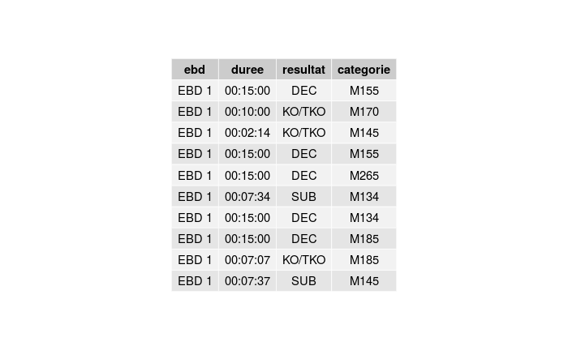

```r
# import des données
EBD <- read_csv("https://raw.githubusercontent.com/xavierbarbier/MMA/master/EBD.csv",
    col_types = cols(duree = col_time(format = "%H:%M:%S")))
ggtexttable(head(EBD,10),rows = NULL)
```

- Ils y a 83 observations pour lesquelles nous avons les variables suivantes : EDB, durée, résultat et catégorie.

### Recherche des données manquantes

```r
# Recherche des NA
sum(is.na(EBD$ebd))
```

```
[1] 0
```

```r
sum(is.na(EBD$duree))
```

```
[1] 0
```

```r
sum(is.na(EBD$resultat))
```

```
[1] 0
```

```r
sum(is.na(EBD$categorie))
```

```
[1] 0
```

- Il n’y pas de besoins de nettoyage ou de correction des données

## 3) Visualisation et résumé des données

### Analyse de l’ensemble des combats

#### Durée moyenne (min)

```r
mean(as.duration(EBD$duree))/60
```

```
[1] 8.180321
```

#### Distribution durée du combat

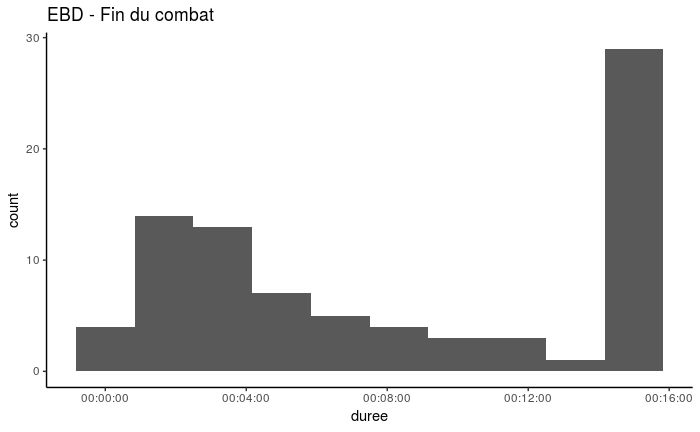

#### Durée du combat

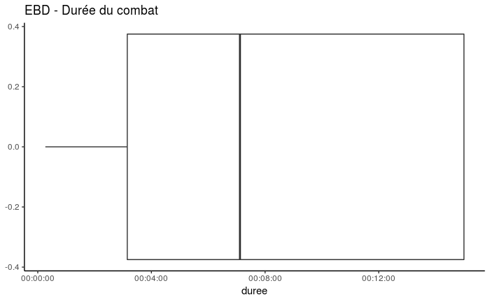

### Durée du combat selon catégorie

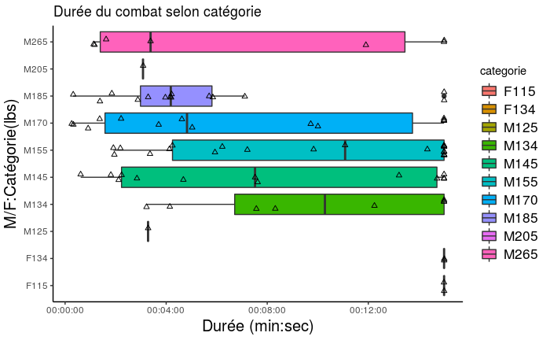

```r
ggplot(data=EBD, aes(x = categorie, y = duree)) +  geom_boxplot(aes(fill=categorie))+ theme_classic() + ggtitle("Durée du combat selon catégorie")+coord_flip()  +
  xlab("M/F:Catégorie(lbs)") + ylab("Durée (min:sec)") + geom_jitter(shape=2, position=position_jitter(0.2)) + theme(legend.text = element_text(size = 13),
                                                                                                                     strip.text.x = element_text(size = 15, face = "bold"),
                                                                                                                     axis.title.y = element_text(color="black", size = 15, vjust=1.5),
                                                                                                                     axis.title.x = element_text(color="black", size = 15),
                                                                                                                     axis.line.y = element_line(colour = "black"))
```

```r
NA
```

## 5) Conclusion

- L’objectif de cette analyse était de déterminer sur les informations de l’UFC sur la durée du combat étaient utilisable pour d’autre niveau de compétition. Pour la durée moyenne, la réponse est non (sous réserve que l’UFC ait utilisée la médiane et non la moyenne). Les combats semblent plus long à l’UFC.
- Concernant la tendance à une relation entre la catégorie de poids et la durée du combat, la réponse est plutôt oui. Les observations des données de l’EBD semblent confirmer les tendances observées à l’UFC. Les catégories de poids plus légères semblent avoir des durées de combat plus importantes.
- es entraîneurs seraient avisés de prendre en compte la durée type selon la catégorie de poids pour construire une stratégie. Celles-ci étant particulièrement grande en relation avec la durée maximale du combat ( 3 x 5 min).